# Boxing Statistics

## 1 Aims and objectives

### 1.1 Introduction

in this report, I will be looking at male boxers and the correlation between their wins, losses, number of total fights. I will attempt to find the correlation between Orthodox and Southpaw fighters and their win rates.

#### descriptions

**Orthodox**

A fighter who fights with **left** hand and foot in front (generally a **right** handed person)

**Southpaw**

A fighter who fights with **right** hand and foot in front (generally a **left** handed person)

This is of great interest to me as I am left handed myself, so I am interested to learn if being in this minority group has some benefits.

#### Background

There is a myth that a Southpaw fighter has an advantage over Orthodox fighters because their fighting stance is more uncommon and rarely seen during training, thus resulting in more a complex fight. Most people agree that this is just a myth; however, it is still told frequently within martial arts communities.

I plan to evaluate the folowing questions:

- If 10% of the general population is lefthanded, does that make 10% of boxers Southpaw?
- How do their wins and losses compare to those of Orthodox boxers?
- Do Southpaws win with more knockouts because their opponents are unable to anticipate their moves?

I will **not** be taking into account who is fighting who; for example, whether the fight is between Orthodox vs Southpaw, Orthodox vs Orthodox, or Southpaw vs Southpaw. I anticipate that this may leave gaps in the data, which I will try to mitigate.

## 1.2 Aims and objectives

The objectives of this project are as follows:

1. To gather a dataset that can be worked on
2. To sanitise and save the dataset to be easily and safely worked on
3. To prove or disprove the theory Southpaw boxers have an advantage other Orthodox fighters
4. To demonstrate that this data is being used ethically
5. To clearly display the results in this report, utilising various techniques

The aims of this project is to answer the following questions:

- Is the ratio of Orthodox to Southpaw boxers the same as the ratio of lefthanded to right handed people in general?
- Do Southpaw boxers have an advantage over Orthodox fighters?
- Which group of fighters are more likely to win by knockout?
- Which group of fighters have a better win:loss ratio?

## 1.3 The data

I chose to use Wikipedia to collect data because their website has all text available under the Creative Commons Attribution-ShareAlike License, which makes it easier to retrieve the data and also safer from a legal perspective.

As Wikipedia has webpages of pure lists, I have found a list of male boxers with each name on the list linking to their individual biographical articles. By utilising the page of lists first, I plan to then extract the desired data from each individeual page.

Wikipedia was also chosen because their website is well structured with pages often following a pattern. For example, a page about a person often has the same information box on the right hand side, which includes their name, a picture, and some basic pieces of data. It is this area of the page that I am specifically interested in.

```python
pip install requests
```

```python
pip install --upgrade pip
```

[output not shown]

# The beginning of the data retrieval process

I ensured that the "List of male boxers" page is available to be read:

```python
response = requests.get(url="https://en.wikipedia.org/wiki/List_of_male_boxers",
)
print(response.status_code)
```

```
200
```

```python
import requests
import urllib.request
from bs4 import BeautifulSoup as bs
import re
import pandas as pd
import matplotlib.pyplot as plt
```

## 1. Creating the data structure

The data structure is set up initially with only the boxers name and the link required to go to their biographical article.

I have chosen to use data frames from pandas as they are easy to manipulate. Later in the process I plan to use the built in ability of pandas to access table data from webpages, which should prove useful as most biographical articles have the same table displaying very similar (if not the same) information.

```python
page = urllib.request.urlopen("https://en.wikipedia.org/wiki/List_of_male_boxers")
soup = bs(page, 'html.parser')

# initialise the lists that will be fed into the data frame
links = []
names = []

allLinks = soup.find(id="bodyContent").find_all("a")
linkToScrape = 0

for link in allLinks:
    if link['href'].find("/wiki/") == -1:
        continue

    # Use this link to scrape
    linkToScrape = link
    links.append(linkToScrape['href'])
    names.append(linkToScrape['title'])


df = pd.DataFrame({'name' : names, 'link': links})
```

## 2. Removing unwanted rows

As you can see below, this data frame contains some rows that are not intended to be used going forward. As there are only a few and as they are ony at the end or beginning of the data, I removed them by hand so to speak.

```python
df
```

|  | name | link |
| --- | --- | --- |
| 0 | Boxing | /wiki/Boxing |
| 1 | List of female boxers | /wiki/List_of_female_boxers |
| 2 | William Abelyan | /wiki/William_Abelyan |
| 3 | Arthur Abraham | /wiki/Arthur_Abraham |
| 4 | Miguel Acosta (boxer) | /wiki/Miguel_Acosta_(boxer) |
| ... | ... | ... |
| 753 | Category:Lists of boxers | /wiki/Category:Lists_of_boxers |
| 754 | Category:Male boxers | /wiki/Category:Male_boxers |
| 755 | Category:Lists of sportsmen | /wiki/Category:Lists_of_sportsmen |
| 756 | Category:Articles with short description | /wiki/Category:Articles_with_short_description |
| 757 | Category:Short description is different from W... | /wiki/Category:Short_description_is_different_... |

758 rows × 2 columns

## 3. Clean data frame

The problematic rows were simply removed with the drop command.

```python
df = df.drop(df.index[:2])
df = df.drop(df.index[749:])
df
```

|  | name | link |
| --- | --- | --- |
| 2 | William Abelyan | /wiki/William_Abelyan |
| 3 | Arthur Abraham | /wiki/Arthur_Abraham |
| 4 | Miguel Acosta (boxer) | /wiki/Miguel_Acosta_(boxer) |
| 5 | Tomasz Adamek | /wiki/Tomasz_Adamek |
| 6 | Ola Afolabi | /wiki/Ola_Afolabi |
| ... | ... | ... |
| 746 | Hein van der Zee | /wiki/Hein_van_der_Zee |
| 747 | Fritzie Zivic | /wiki/Fritzie_Zivic |
| 748 | Stefano Zoff | /wiki/Stefano_Zoff |
| 749 | Henriques Zowa | /wiki/Henriques_Zowa |
| 750 | Fulgencio Zúñiga | /wiki/Fulgencio_Z%C3%BA%C3%B1iga |

749 rows × 2 columns

## 4. Testing the links

This for loop adds the biographical article to the end of Wikipedias standard URL, then prints them to the screen. This allows me to confirm that the links are correct and will work for the next step.

```python
for link in df['link']:
    print("https://en.wikipedia.org" + link)
```

```
https://en.wikipedia.org/wiki/William_Abelyan
https://en.wikipedia.org/wiki/Arthur_Abraham
https://en.wikipedia.org/wiki/Miguel_Acosta_(boxer)
https://en.wikipedia.org/wiki/Tomasz_Adamek
https://en.wikipedia.org/wiki/Ola_Afolabi
https://en.wikipedia.org/wiki/Joachim_Alcine
https://en.wikipedia.org/wiki/Devon_Alexander
https://en.wikipedia.org/wiki/Jos%C3%A9_Alfaro
https://en.wikipedia.org/wiki/Muhammad_Ali
https://en.wikipedia.org/wiki/Elvis_%C3%81lvarez
https://en.wikipedia.org/wiki/Sa%C3%BAl_%C3%81lvarez
https://en.wikipedia.org/wiki/Lou_Ambers
https://en.wikipedia.org/wiki/Sammy_Angott
https://en.wikipedia.org/wiki/Alfredo_Angulo
https://en.wikipedia.org/wiki/Vito_Antuofermo
https://en.wikipedia.org/wiki/Fred_Apostoli
https://en.wikipedia.org/wiki/Roman_Aramian
https://en.wikipedia.org/wiki/Jorge_Arce
https://en.wikipedia.org/wiki/Alexis_Arg%C3%BCello
https://en.wikipedia.org/wiki/Henry_Armstrong
https://en.wikipedia.org/wiki/Mike_Arnaoutis
https://en.wikipedia.org/wiki/Chris_Arreola
https://en.wikipedia.org/wiki/Lenin_Arroyo
https://en.wikipedia.org/wiki/Mike_Alvarado
https://en.wikipedia.org/wiki/Alex_Arthur
https://en.wikipedia.org/wiki/Amin_Asikainen
https://en.wikipedia.org/wiki/Abe_Attell
https://en.wikipedia.org/wiki/Emanuel_Augustus
https://en.wikipedia.org/wiki/Ray_Austin_(boxer)
https://en.wikipedia.org/wiki/Bonifacio_%C3%81vila
https://en.wikipedia.org/wiki/Alexander_Awdijan
https://en.wikipedia.org/wiki/Selcuk_Aydin
https://en.wikipedia.org/wiki/Billy_Backus
https://en.wikipedia.org/wiki/Tony_Badea
https://en.wikipedia.org/wiki/Buddy_Baer
https://en.wikipedia.org/wiki/Max_Baer_(boxer)
https://en.wikipedia.org/wiki/Joe_Baksi
https://en.wikipedia.org/wiki/Bob_Baker_(boxer)
https://en.wikipedia.org/wiki/Carlos_Baldomir
https://en.wikipedia.org/wiki/Carlos_Balderas
```

[output cut: 694 more lines]

```
https://en.wikipedia.org/wiki/Yasuei_Yakushiji
https://en.wikipedia.org/wiki/Teddy_Yarosz
https://en.wikipedia.org/wiki/Jimmy_Young_(boxer)
https://en.wikipedia.org/wiki/Tony_Zale
https://en.wikipedia.org/wiki/Tom_Zbikowski
https://en.wikipedia.org/wiki/Alfonso_Zamora
https://en.wikipedia.org/wiki/Ysaias_Zamudio
https://en.wikipedia.org/wiki/Daniel_Zaragoza
https://en.wikipedia.org/wiki/Carlos_Z%C3%A1rate_Serna
https://en.wikipedia.org/wiki/Dejan_Zavec
https://en.wikipedia.org/wiki/Hein_van_der_Zee
https://en.wikipedia.org/wiki/Fritzie_Zivic
https://en.wikipedia.org/wiki/Stefano_Zoff
https://en.wikipedia.org/wiki/Henriques_Zowa
https://en.wikipedia.org/wiki/Fulgencio_Z%C3%BA%C3%B1iga
```

## 5. The function

Below is the function that does much of the heavy lifting. The boxerScrape function uses the links found earlier to visit each biographic article for each person on the list and finds the appropriate data from the info table.

The function ends immediately if the webpage is not responding and gives an appropriate error message.

We initialise the variables that are used to populate the dictionary object. This way, if a piece of data is missing, a 0 or an empty string is then given instead of the program failing or giving NaN.

In the for loop, if a specific heading exists, then the variable is updated to hold the information next to the correct heading. Here we also print what we have found, so we can see that it is working correctly while the function is working. By doing this, we do not need to wait for the function to finish to know if there were any problems. I have not seen a big performance difference, so i chose to keep them for ease of use of the program.

Finally, the dictionary object is returned.

```python
def boxerScrape(link):

    response = requests.get(url=link)
#   check that the webpage is available
    if response.status_code != 200:
        return "something went wrong: " + link
#   initialise the variables that will be put into the dictionary object
    nationality = ''
    stance = ''
    total = 0
    wins = 0
    ko = 0
    losses = 0
    draws = 0
#   printing the link here helps if there is an error,
#   errors often happen after this step so knowing the page the error came from is very helpful
    print(link)
#   try and except block, prevents the program from failing if there is an erorr,
#   instead prints a message to the console
    try:
#       scrape all the table elements using pandas
        scraper = pd.read_html(link)
#       put the first table into our temporary dataframe
        data = pd.DataFrame(scraper[0])
#       loop over the dataframe to pick out the information that we are looking for
        for row in data.index:
            if data.iloc[row][0] == 'Nationality':
                print ('Nationality = ' + data.iloc[row][1])
                nationality = data.iloc[row][1]
            if data.iloc[row][0] == 'Stance':
                print ('stance = ' + data.iloc[row][1])
                stance = data.iloc[row][1]
            if data.iloc[row][0] == 'Total fights':
                print ('total = ' + data.iloc[row][1])
                total = data.iloc[row][1]
            if data.iloc[row][0] == 'Wins':
                print ('wins = ' + data.iloc[row][1])
                wins = data.iloc[row][1]
            if data.iloc[row][0] == 'Wins by KO':
                print ('KO = ' + data.iloc[row][1])
                ko = data.iloc[row][1]
            if data.iloc[row][0] == 'Losses':
                print ('losses = ' + data.iloc[row][1])
                losses = data.iloc[row][1]
            if data.iloc[row][0] == 'Draws':
                print ('draws = ' + data.iloc[row][1])
                draws = data.iloc[row][1]
#       populate the dictionary with the information we were able to scrape.
        dict = {'Nationality': nationality,
                'Stance' : stance,
                'Total fights': total,
                'Wins': wins,
                'KO': ko,
                'Losses': losses,
                'Draws': draws}
    except:
        print("an error occured")
        return
#   return the dictionary
    return dict
```

## 6. Calling the function

A new data frame is created to take the dictionary returned from the function.

We loop over all the links using the same for loop that was tested in step 4, but this time calling the function that I described earlier.

Another temporary data frame is used to recieve the dictionary, then it is concatenated with the output dataframe to form our main set of data which will be used later.

```python
output = pd.DataFrame()
# loop over all the links we found
for link in df['link']:
#   call the function and put the returned information directly into a variable
    data = boxerScrape("https://en.wikipedia.org" + link)

    print(data)
#   populate the output dataframe
    df_dictionary = pd.DataFrame([data])
    output = pd.concat([output, df_dictionary], ignore_index=True)
    print(output.head())
```

```
https://en.wikipedia.org/wiki/William_Abelyan
Nationality = Armenian
stance = Southpaw
total = 31
wins = 24
KO = 13
losses = 6
draws = 1
{'Nationality': 'Armenian', 'Stance': 'Southpaw', 'Total fights': '31', 'Wins': '24', 'KO': '13', 'Losses': '6', 'Draws': '1'}
  Nationality    Stance Total fights Wins  KO Losses Draws
0    Armenian  Southpaw           31   24  13      6     1
https://en.wikipedia.org/wiki/Arthur_Abraham
Nationality = Armenian German
stance = Orthodox
total = 53
wins = 47
KO = 30
losses = 6
{'Nationality': 'Armenian German', 'Stance': 'Orthodox', 'Total fights': '53', 'Wins': '47', 'KO': '30', 'Losses': '6', 'Draws': 0}
       Nationality    Stance Total fights Wins  KO Losses Draws
0         Armenian  Southpaw           31   24  13      6     1
1  Armenian German  Orthodox           53   47  30      6     0
https://en.wikipedia.org/wiki/Miguel_Acosta_(boxer)
Nationality = Venezuelan
stance = Orthodox
total = 40
wins = 29
KO = 23
losses = 9
draws = 2
{'Nationality': 'Venezuelan', 'Stance': 'Orthodox', 'Total fights': '40', 'Wins': '29', 'KO': '23', 'Losses': '9', 'Draws': '2'}
       Nationality    Stance Total fights Wins  KO Losses Draws
0         Armenian  Southpaw           31   24  13      6     1
1  Armenian German  Orthodox           53   47  30      6     0
2       Venezuelan  Orthodox           40   29  23      9     2
https://en.wikipedia.org/wiki/Tomasz_Adamek
Nationality = Polish
total = 59
wins = 53
KO = 31
```

[output cut: 9012 more lines]

```
https://en.wikipedia.org/wiki/Fulgencio_Z%C3%BA%C3%B1iga
Nationality = Colombian
stance = Orthodox
total = 46
wins = 28
KO = 25
losses = 17
draws = 1
{'Nationality': 'Colombian', 'Stance': 'Orthodox', 'Total fights': '46', 'Wins': '28', 'KO': '25', 'Losses': '17', 'Draws': '1'}
     0 Draws  KO Losses      Nationality    Stance Total fights Wins
0  NaN     1  13      6         Armenian  Southpaw           31   24
1  NaN     0  30      6  Armenian German  Orthodox           53   47
2  NaN     2  23      9       Venezuelan  Orthodox           40   29
3  NaN     0  31      6           Polish                     59   53
4  NaN     0   0      0                                       0    0
```

## 7. Cleansing the data

The output data frame has an erroneous column that needs to be removed, and the 'df' data frame has incorrect indexing created by removing rows earlier, the index needs to be reset before merging the dataframes.

```python
output
```

|  | 0 | Draws | KO | Losses | Nationality | Stance | Total fights | Wins |
| --- | --- | --- | --- | --- | --- | --- | --- | --- |
| 0 | NaN | 1 | 13 | 6 | Armenian | Southpaw | 31 | 24 |
| 1 | NaN | 0 | 30 | 6 | Armenian German | Orthodox | 53 | 47 |
| 2 | NaN | 2 | 23 | 9 | Venezuelan | Orthodox | 40 | 29 |
| 3 | NaN | 0 | 31 | 6 | Polish |  | 59 | 53 |
| 4 | NaN | 0 | 0 | 0 |  |  | 0 | 0 |
| ... | ... | ... | ... | ... | ... | ... | ... | ... |
| 744 | NaN | 0 | 0 | 0 |  |  | 0 | 0 |
| 745 | NaN | 10 | 81 | 65 | American | Orthodox | 233 | 158 |
| 746 | NaN | 3 | 17 | 12 | Italian | Orthodox | 58 | 43 |
| 747 | NaN | 2 | 0 | 11 | Angolan Dutch | Orthodox | 0 | 32 |
| 748 | NaN | 1 | 25 | 17 | Colombian | Orthodox | 46 | 28 |

749 rows × 8 columns

```python
output = output.drop([0],axis=1)
output
```

|  | Draws | KO | Losses | Nationality | Stance | Total fights | Wins |
| --- | --- | --- | --- | --- | --- | --- | --- |
| 0 | 1 | 13 | 6 | Armenian | Southpaw | 31 | 24 |
| 1 | 0 | 30 | 6 | Armenian German | Orthodox | 53 | 47 |
| 2 | 2 | 23 | 9 | Venezuelan | Orthodox | 40 | 29 |
| 3 | 0 | 31 | 6 | Polish |  | 59 | 53 |
| 4 | 0 | 0 | 0 |  |  | 0 | 0 |
| ... | ... | ... | ... | ... | ... | ... | ... |
| 744 | 0 | 0 | 0 |  |  | 0 | 0 |
| 745 | 10 | 81 | 65 | American | Orthodox | 233 | 158 |
| 746 | 3 | 17 | 12 | Italian | Orthodox | 58 | 43 |
| 747 | 2 | 0 | 11 | Angolan Dutch | Orthodox | 0 | 32 |
| 748 | 1 | 25 | 17 | Colombian | Orthodox | 46 | 28 |

749 rows × 7 columns

```python
df = df.reset_index(drop=True)
df
```

|  | name | link |
| --- | --- | --- |
| 0 | William Abelyan | /wiki/William_Abelyan |
| 1 | Arthur Abraham | /wiki/Arthur_Abraham |
| 2 | Miguel Acosta (boxer) | /wiki/Miguel_Acosta_(boxer) |
| 3 | Tomasz Adamek | /wiki/Tomasz_Adamek |
| 4 | Ola Afolabi | /wiki/Ola_Afolabi |
| ... | ... | ... |
| 744 | Hein van der Zee | /wiki/Hein_van_der_Zee |
| 745 | Fritzie Zivic | /wiki/Fritzie_Zivic |
| 746 | Stefano Zoff | /wiki/Stefano_Zoff |
| 747 | Henriques Zowa | /wiki/Henriques_Zowa |
| 748 | Fulgencio Zúñiga | /wiki/Fulgencio_Z%C3%BA%C3%B1iga |

749 rows × 2 columns

## 8. Bringing them together

Both of our dataframes (output and df) have the same number of rows, which means the function worked correctly. If a link was missing, it would not populate the output dataframe and would return fewer that 749 rows.

Once merged, we can finally begin analysing this data.

```python
df_output = pd.concat([df, output], axis = 1)
```

```python
df_output
```

|  | name | link | Draws | KO | Losses | Nationality | Stance | Total fights | Wins |
| --- | --- | --- | --- | --- | --- | --- | --- | --- | --- |
| 0 | William Abelyan | /wiki/William_Abelyan | 1 | 13 | 6 | Armenian | Southpaw | 31 | 24 |
| 1 | Arthur Abraham | /wiki/Arthur_Abraham | 0 | 30 | 6 | Armenian German | Orthodox | 53 | 47 |
| 2 | Miguel Acosta (boxer) | /wiki/Miguel_Acosta_(boxer) | 2 | 23 | 9 | Venezuelan | Orthodox | 40 | 29 |
| 3 | Tomasz Adamek | /wiki/Tomasz_Adamek | 0 | 31 | 6 | Polish |  | 59 | 53 |
| 4 | Ola Afolabi | /wiki/Ola_Afolabi | 0 | 0 | 0 |  |  | 0 | 0 |
| ... | ... | ... | ... | ... | ... | ... | ... | ... | ... |
| 744 | Hein van der Zee | /wiki/Hein_van_der_Zee | 0 | 0 | 0 |  |  | 0 | 0 |
| 745 | Fritzie Zivic | /wiki/Fritzie_Zivic | 10 | 81 | 65 | American | Orthodox | 233 | 158 |
| 746 | Stefano Zoff | /wiki/Stefano_Zoff | 3 | 17 | 12 | Italian | Orthodox | 58 | 43 |
| 747 | Henriques Zowa | /wiki/Henriques_Zowa | 2 | 0 | 11 | Angolan Dutch | Orthodox | 0 | 32 |
| 748 | Fulgencio Zúñiga | /wiki/Fulgencio_Z%C3%BA%C3%B1iga | 1 | 25 | 17 | Colombian | Orthodox | 46 | 28 |

749 rows × 9 columns

## 9. Writing to .csv

now that the data has been saved to a csv file, we can more easily and safely manipulate the data

```python
df_output.to_csv('boxers.csv', sep = ',', index=False)
```

## 10. Reading from the .csv

```python
boxersData = pd.read_csv('boxers.csv')
```

### 10.1 cleaning again

```python
boxersData
```

|  | name | link | Draws | KO | Losses | Nationality | Stance | Total fights | Wins |
| --- | --- | --- | --- | --- | --- | --- | --- | --- | --- |
| 0 | William Abelyan | /wiki/William_Abelyan | 1 | 13 | 6 | Armenian | Southpaw | 31 | 24 |
| 1 | Arthur Abraham | /wiki/Arthur_Abraham | 0 | 30 | 6 | Armenian German | Orthodox | 53 | 47 |
| 2 | Miguel Acosta (boxer) | /wiki/Miguel_Acosta_(boxer) | 2 | 23 | 9 | Venezuelan | Orthodox | 40 | 29 |
| 3 | Tomasz Adamek | /wiki/Tomasz_Adamek | 0 | 31 | 6 | Polish | NaN | 59 | 53 |
| 4 | Ola Afolabi | /wiki/Ola_Afolabi | 0 | 0 | 0 | NaN | NaN | 0 | 0 |
| ... | ... | ... | ... | ... | ... | ... | ... | ... | ... |
| 744 | Hein van der Zee | /wiki/Hein_van_der_Zee | 0 | 0 | 0 | NaN | NaN | 0 | 0 |
| 745 | Fritzie Zivic | /wiki/Fritzie_Zivic | 10 | 81 | 65 | American | Orthodox | 233 | 158 |
| 746 | Stefano Zoff | /wiki/Stefano_Zoff | 3 | 17 | 12 | Italian | Orthodox | 58 | 43 |
| 747 | Henriques Zowa | /wiki/Henriques_Zowa | 2 | 0 | 11 | Angolan Dutch | Orthodox | 0 | 32 |
| 748 | Fulgencio Zúñiga | /wiki/Fulgencio_Z%C3%BA%C3%B1iga | 1 | 25 | 17 | Colombian | Orthodox | 46 | 28 |

749 rows × 9 columns

### 10.2 NaN entries

Removing the NaN entries from the data frame, and replacing them with a string "-"

This should prevent errors when parsing the data

```python
boxersData['Nationality'] = boxersData['Nationality'].fillna('-')
boxersData['Stance'] = boxersData['Stance'].fillna('-')
```

```python
boxersData
```

|  | name | link | Draws | KO | Losses | Nationality | Stance | Total fights | Wins |
| --- | --- | --- | --- | --- | --- | --- | --- | --- | --- |
| 0 | William Abelyan | /wiki/William_Abelyan | 1 | 13 | 6 | Armenian | Southpaw | 31 | 24 |
| 1 | Arthur Abraham | /wiki/Arthur_Abraham | 0 | 30 | 6 | Armenian German | Orthodox | 53 | 47 |
| 2 | Miguel Acosta (boxer) | /wiki/Miguel_Acosta_(boxer) | 2 | 23 | 9 | Venezuelan | Orthodox | 40 | 29 |
| 3 | Tomasz Adamek | /wiki/Tomasz_Adamek | 0 | 31 | 6 | Polish | - | 59 | 53 |
| 4 | Ola Afolabi | /wiki/Ola_Afolabi | 0 | 0 | 0 | - | - | 0 | 0 |
| ... | ... | ... | ... | ... | ... | ... | ... | ... | ... |
| 744 | Hein van der Zee | /wiki/Hein_van_der_Zee | 0 | 0 | 0 | - | - | 0 | 0 |
| 745 | Fritzie Zivic | /wiki/Fritzie_Zivic | 10 | 81 | 65 | American | Orthodox | 233 | 158 |
| 746 | Stefano Zoff | /wiki/Stefano_Zoff | 3 | 17 | 12 | Italian | Orthodox | 58 | 43 |
| 747 | Henriques Zowa | /wiki/Henriques_Zowa | 2 | 0 | 11 | Angolan Dutch | Orthodox | 0 | 32 |
| 748 | Fulgencio Zúñiga | /wiki/Fulgencio_Z%C3%BA%C3%B1iga | 1 | 25 | 17 | Colombian | Orthodox | 46 | 28 |

749 rows × 9 columns

### 10.3 Correcting missing data

Below is a list of rows in the dataset that do not have data for total fights, but do have data for the other heading. This can be corrected by adding together the other entries (excluding KO, because they are already counted in wins) to give the missing total.

```python
boxersData.loc[(boxersData['Total fights'] == 0) & (boxersData['Wins'] !=  0)]
```

|  | name | link | Draws | KO | Losses | Nationality | Stance | Total fights | Wins |
| --- | --- | --- | --- | --- | --- | --- | --- | --- | --- |
| 52 | Robert Berridge | /wiki/Robert_Berridge | 1 | 0 | 8 | New Zealand | Southpaw | 0 | 30 |
| 57 | Adam Braidwood | /wiki/Adam_Braidwood | 0 | 0 | 0 | Canadian | Orthodox | 0 | 1 |
| 62 | Lucas Browne | /wiki/Lucas_Browne | 0 | 0 | 2 | - | - | 0 | 6 |
| 80 | Daniel Dawson | /wiki/Daniel_Dawson | 1 | 0 | 14 | Australian | Orthodox | 0 | 54 |
| 91 | Nate Diaz | /wiki/Nate_Diaz | 0 | 0 | 13 | - | Southpaw | 0 | 22 |
| 92 | Nick Diaz | /wiki/Nick_Diaz | 0 | 0 | 10 | - | - | 0 | 26 |
| 153 | Ryan Ford (fighter) | /wiki/Ryan_Ford_(fighter) | 0 | 0 | 5 | Canadian | - | 0 | 24 |
| 192 | Rodney Glunder | /wiki/Rodney_Glunder | 3 | 0 | 20 | Dutch | Orthodox | 0 | 25 |
| 415 | Boyd Melson | /wiki/Boyd_Melson | 1 | 4 | 2 | United States | - | 0 | 15 |
| 486 | Sven Ottke | /wiki/Sven_Ottke | 5 | 0 | 47 | German | Orthodox | 0 | 256 |
| 544 | Sam Rapira (boxer) | /wiki/Sam_Rapira_(boxer) | 0 | 0 | 11 | - | Orthodox | 0 | 59 |
| 552 | Nick Ring | /wiki/Nick_Ring | 0 | 0 | 4 | American | - | 0 | 14 |
| 578 | Alessio Sakara | /wiki/Alessio_Sakara | 0 | 0 | 13 | Italian | - | 0 | 21 |
| 588 | Tom Sayers | /wiki/Tom_Sayers | 3 | 0 | 1 | British | - | 0 | 12 |
| 609 | Anderson Silva | /wiki/Anderson_Silva | 0 | 0 | 11 | Brazilian American[4] | - | 0 | 34 |
| 647 | Glover Teixeira | /wiki/Glover_Teixeira | 0 | 0 | 8 | Brazilian American | - | 0 | 33 |
| 677 | Alexander Ustinov | /wiki/Alexander_Ustinov | 1 | 0 | 2 | Russian | Orthodox | 0 | 1 |
| 747 | Henriques Zowa | /wiki/Henriques_Zowa | 2 | 0 | 11 | Angolan Dutch | Orthodox | 0 | 32 |

### 10.4 Correcting missing data, continued

The script below loops over the data frame and adds wins, losses, and draws together if the total fights = 0 but one of the other headings mentioned != 0, Total fights will be recalculated

```python
for index, row in boxersData.iterrows():
    if (row['Total fights'] == 0):
        if (row['Wins'] != 0 or row['Losses'] != 0 or row['Draws'] != 0):
            row['Total fights'] = (row['Wins'] + row['Losses'] + row['Draws'])
            print(row['Total fights'])
```

### 10.5 Checking it worked

As we can see, the list produced is now empty, meaning that there are no more 'Total fights' entries that are 0 erroneously.

```python
boxersData.loc[(boxersData['Total fights'] == 0) & (boxersData['Wins'] !=  0)]
```

|  | name | link | Draws | KO | Losses | Nationality | Stance | Total fights | Wins |
| --- | --- | --- | --- | --- | --- | --- | --- | --- | --- |

## 11. Calculating the percentage of Southpaw fighters

Here I will attempt to find the percentage of fighters that are Southpaw, and compare that to the global average of lefthanded people.

```python
orth = 0
south = 0
none = 0

for index, row in boxersData.iterrows():
    if (row['Stance'][0] == 'O' ):
        orth = orth +1
    if (row['Stance'][0] == 'S'):
        south = south +1
    if (row['Stance'] == '-'):
        none = none +1


stance_dict = {'Orthodox': orth, 'Southpaw': south, 'No data': none}
stance_dict
percent = south / (south+orth) *100
percent = str(percent)
print(stance_dict)
print("the percentage of southpaw fighters is: " + percent)
```

```
{'Orthodox': 373, 'Southpaw': 83, 'No data': 284}
the percentage of southpaw fighters is: 18.201754385964914
```

### 11.1 Visualising the result

Above we can see the percentage of Southpaw fighters is 18.2% according to the data available.

This is interesting because the percentage of the general public being left handed is around 10% on average.

According to a study of 2.3 million people published in *the Psychological Bulletin* (Papadatou-Pastou et al., 2020), a meta-analysis of 262 datasets found left handedness ranged from 9.3% to 18.1%. I find it difficult, but not impossible, to believe that the number of Southpaw professional fighters is a coincidence.

The bar graph below shows the number of Orthodox compared to the number of Southpaw fighters. There are also many entries with no data under this heading, but can be reviewed later to see if it makes a difference.

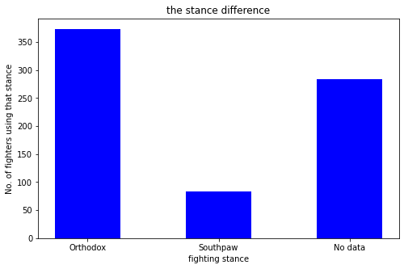

```python
stance = list(stance_dict.keys())
values = list(stance_dict.values())

fig = plt.figure(figsize = (8, 5))

plt.bar(stance, values, color ='blue',
        width = 0.5)

plt.xlabel("fighting stance")
plt.ylabel("No. of fighters using that stance")
plt.title("the stance difference")
plt.show()
```

## 12. Calculating the difference in performance

As set out in my aims and objectives, I seek to discover if there really is an advantage to being left handed as a professional boxer. I shall take the average of both sets of boxers for each heading.

```python
ms = pd.DataFrame(boxersData[boxersData['Stance'] == 'Southpaw'].mean())
mo = pd.DataFrame(boxersData[boxersData['Stance'] == 'Orthodox'].mean())
ms = ms.rename(columns={0:'Southpaw'})
mo = mo.rename(columns={0:'Orthodox'})
extract = ms['Southpaw']
mm = mo.join(extract)
```

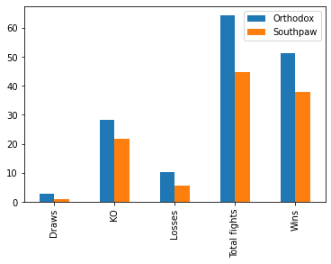

```python
mm.plot(kind='bar')
```

### 12.1 The result

Both sets of boxers above have similar trends to their wins, losses, draws, and total fights, which I found interesting. We see that Orthodox fighters have higher averages in all aspects, but that doesn't necessarily mean that they are better fighters. Next is evaluating the percentage of wins to losses for each group.

```python
percent_s_wins = (mm.loc['Wins','Southpaw'] / mm.loc['Total fights','Southpaw']) *100
percent_o_wins = (mm.loc['Wins','Orthodox'] / mm.loc['Total fights','Orthodox']) *100

win_percent = {'Win %': [percent_o_wins, percent_s_wins]}
win_percent = pd.DataFrame.from_dict(win_percent, orient='index')
win_percent = win_percent.rename(columns={0:'Orthodox',1:'Southpaw'})
```

```python
mm = mm.append(win_percent)
mm
```

|  | Orthodox | Southpaw |
| --- | --- | --- |
| Draws | 2.721622 | 1.075000 |
| KO | 28.378378 | 21.850000 |
| Losses | 10.421622 | 5.675000 |
| Total fights | 64.256757 | 44.700000 |
| Wins | 51.113514 | 37.950000 |
| Win % | 79.545741 | 84.899329 |

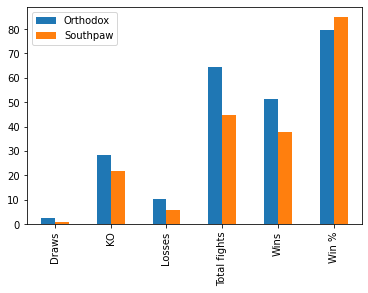

```python
mm.plot(kind='bar')
```

### 12.2 The result, continued

Above is what I was hoping to see. While small, on average, a Southpaw fighter wins more of their fights than an Orthodox fighter, showing that there may be some advantage to being Southpaw.

```python
boxersData.describe()
```

|  | Draws | KO | Losses | Total fights | Wins |
| --- | --- | --- | --- | --- | --- |
| count | 749.000000 | 749.000000 | 749.000000 | 749.000000 | 749.000000 |
| mean | 1.534045 | 17.285714 | 6.088117 | 38.718291 | 31.096128 |
| std | 4.451519 | 18.684077 | 13.150008 | 46.633621 | 35.909294 |
| min | 0.000000 | 0.000000 | 0.000000 | 0.000000 | 0.000000 |
| 25% | 0.000000 | 0.000000 | 0.000000 | 0.000000 | 0.000000 |
| 50% | 0.000000 | 16.000000 | 3.000000 | 35.000000 | 29.000000 |
| 75% | 1.000000 | 28.000000 | 8.000000 | 52.000000 | 43.000000 |
| max | 55.000000 | 126.000000 | 276.000000 | 359.000000 | 302.000000 |

### Some more cleaning

There are a large number of entries that have no data at all with seemingly no way to fix them. This may have been an error on my part with the way I gathered the data.

To investigate, I followed a number of the links which returned no data; these pages were either flagged as being incomplete, or having issues such as:

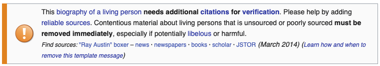

This may be a blessing in disguise, as this error has given us a filter, which doesn't allow me access to the pages that may have unreliable data. I am going to call this a feature instead of a bug, because I would rather have quality over quantity for this study.

The other factor that affected the data is when a person had a varied career. This was the case of Tom Zbikowski, who was listed as boxer despite his table only featureing his career as an NFL football player

[figure not shown]

### Some more cleaning, continued

In the following cells, I will isolate and remove rows that have no data at all, then I will repeat the previous tests to see if the empty data was making a difference.

```python
boxersData.loc[(boxersData['Total fights'] == 0)]
```

|  | name | link | Draws | KO | Losses | Nationality | Stance | Total fights | Wins |
| --- | --- | --- | --- | --- | --- | --- | --- | --- | --- |
| 4 | Ola Afolabi | /wiki/Ola_Afolabi | 0 | 0 | 0 | - | - | 0 | 0 |
| 15 | Fred Apostoli | /wiki/Fred_Apostoli | 0 | 0 | 0 | - | - | 0 | 0 |
| 16 | Roman Aramian | /wiki/Roman_Aramian | 0 | 0 | 0 | - | - | 0 | 0 |
| 18 | Alexis Argüello | /wiki/Alexis_Arg%C3%BCello | 0 | 0 | 0 | - | - | 0 | 0 |
| 28 | Ray Austin (boxer) | /wiki/Ray_Austin_(boxer) | 0 | 0 | 0 | - | - | 0 | 0 |
| ... | ... | ... | ... | ... | ... | ... | ... | ... | ... |
| 732 | Winky Wright | /wiki/Winky_Wright | 0 | 0 | 0 | - | - | 0 | 0 |
| 734 | Yasuei Yakushiji | /wiki/Yasuei_Yakushiji | 0 | 0 | 0 | - | - | 0 | 0 |
| 738 | Tom Zbikowski | /wiki/Tom_Zbikowski | 0 | 0 | 0 | - | - | 0 | 0 |
| 740 | Ysaias Zamudio | /wiki/Ysaias_Zamudio | 0 | 0 | 0 | - | - | 0 | 0 |
| 744 | Hein van der Zee | /wiki/Hein_van_der_Zee | 0 | 0 | 0 | - | - | 0 | 0 |

257 rows × 9 columns

```python
boxersData = boxersData.loc[boxersData["Total fights"] > 0]
```

```python
boxersData
```

|  | name | link | Draws | KO | Losses | Nationality | Stance | Total fights | Wins |
| --- | --- | --- | --- | --- | --- | --- | --- | --- | --- |
| 0 | William Abelyan | /wiki/William_Abelyan | 1 | 13 | 6 | Armenian | Southpaw | 31 | 24 |
| 1 | Arthur Abraham | /wiki/Arthur_Abraham | 0 | 30 | 6 | Armenian German | Orthodox | 53 | 47 |
| 2 | Miguel Acosta (boxer) | /wiki/Miguel_Acosta_(boxer) | 2 | 23 | 9 | Venezuelan | Orthodox | 40 | 29 |
| 3 | Tomasz Adamek | /wiki/Tomasz_Adamek | 0 | 31 | 6 | Polish | - | 59 | 53 |
| 5 | Joachim Alcine | /wiki/Joachim_Alcine | 2 | 21 | 8 | Canadian Haitian | Orthodox | 45 | 35 |
| ... | ... | ... | ... | ... | ... | ... | ... | ... | ... |
| 743 | Dejan Zavec | /wiki/Dejan_Zavec | 0 | 19 | 4 | Slovenian | Orthodox | 39 | 35 |
| 745 | Fritzie Zivic | /wiki/Fritzie_Zivic | 10 | 81 | 65 | American | Orthodox | 233 | 158 |
| 746 | Stefano Zoff | /wiki/Stefano_Zoff | 3 | 17 | 12 | Italian | Orthodox | 58 | 43 |
| 747 | Henriques Zowa | /wiki/Henriques_Zowa | 2 | 0 | 11 | Angolan Dutch | Orthodox | 45 | 32 |
| 748 | Fulgencio Zúñiga | /wiki/Fulgencio_Z%C3%BA%C3%B1iga | 1 | 25 | 17 | Colombian | Orthodox | 46 | 28 |

492 rows × 9 columns

```python
boxersData.loc[(boxersData['Total fights'] == 0)]
```

|  | name | link | Draws | KO | Losses | Nationality | Stance | Total fights | Wins |
| --- | --- | --- | --- | --- | --- | --- | --- | --- | --- |

```python
boxersData.describe()
```

|  | Draws | KO | Losses | Total fights | Wins |
| --- | --- | --- | --- | --- | --- |
| count | 492.000000 | 492.000000 | 492.000000 | 492.000000 | 492.000000 |
| mean | 2.335366 | 26.315041 | 9.268293 | 58.943089 | 47.339431 |
| std | 5.320993 | 17.138478 | 15.293769 | 46.026478 | 34.552900 |
| min | 0.000000 | 0.000000 | 0.000000 | 1.000000 | 0.000000 |
| 25% | 0.000000 | 16.000000 | 3.000000 | 35.000000 | 29.000000 |
| 50% | 1.000000 | 24.000000 | 6.000000 | 46.000000 | 39.000000 |
| 75% | 2.000000 | 33.000000 | 11.000000 | 66.000000 | 55.000000 |
| max | 55.000000 | 126.000000 | 276.000000 | 359.000000 | 302.000000 |

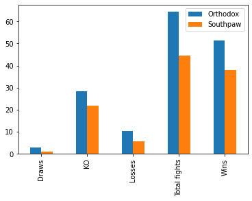

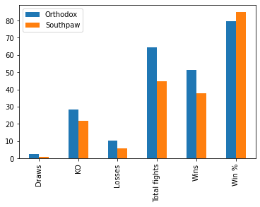

```python
ms = pd.DataFrame(boxersData[boxersData['Stance'] == 'Southpaw'].mean())
mo = pd.DataFrame(boxersData[boxersData['Stance'] == 'Orthodox'].mean())
ms = ms.rename(columns={0:'Southpaw'})
mo = mo.rename(columns={0:'Orthodox'})
extract = ms['Southpaw']
extract
mm = mo.join(extract)

mm.plot(kind='bar')

percent_s_wins = (mm.loc['Wins','Southpaw'] / mm.loc['Total fights','Southpaw']) *100
percent_o_wins = (mm.loc['Wins','Orthodox'] / mm.loc['Total fights','Orthodox']) *100

win_percent = {'Win %': [percent_o_wins, percent_s_wins]}
win_percent = pd.DataFrame.from_dict(win_percent, orient='index')
win_percent = win_percent.rename(columns={0:'Orthodox',1:'Southpaw'})

mm = mm.append(win_percent)
mm

mm.plot(kind='bar')
```

```python
mm
```

|  | Orthodox | Southpaw |
| --- | --- | --- |
| Draws | 2.728997 | 1.075000 |
| KO | 28.455285 | 21.850000 |
| Losses | 10.449864 | 5.675000 |
| Total fights | 64.430894 | 44.700000 |
| Wins | 51.252033 | 37.950000 |
| Win % | 79.545741 | 84.899329 |

```python
orth = 0
south = 0
none = 0

for index, row in boxersData.iterrows():
    if (row['Stance'][0] == 'O' ):
        orth = orth +1
    if (row['Stance'][0] == 'S'):
        south = south +1
    if (row['Stance'] == '-'):
        none = none +1


stance_dict = {'Orthodox': orth, 'Southpaw': south, 'No data': none}
stance_dict
percent = south / (south+orth) *100
percent = str(percent)
print(stance_dict)
print("the percentage of southpaw fighters is: " + percent)
```

```
{'Orthodox': 372, 'Southpaw': 83, 'No data': 28}
the percentage of southpaw fighters is: 18.24175824175824
```

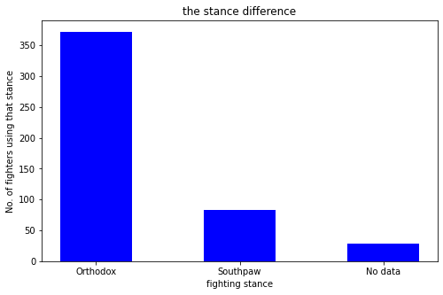

```python
stance = list(stance_dict.keys())
values = list(stance_dict.values())

fig = plt.figure(figsize = (8, 5))

plt.bar(stance, values, color ='blue',
        width = 0.5)

plt.xlabel("fighting stance")
plt.ylabel("No. of fighters using that stance")
plt.title("the stance difference")
plt.show()
```

## The difference

It seemed like the rows with no data had no appreciable effect on the results we have already seen. Now that the data is a little cleaner, we can continue.

We previously looked at the win rate, let's now look at the knock out rate.

```python
percent_s_ko = (mm.loc['KO','Southpaw'] / mm.loc['Wins','Southpaw']) *100
percent_o_ko = (mm.loc['KO','Orthodox'] / mm.loc['Wins','Orthodox']) *100

ko_percent = {'KO %': [percent_o_ko, percent_s_ko]}
ko_percent = pd.DataFrame.from_dict(ko_percent, orient='index')
ko_percent = ko_percent.rename(columns={0:'Orthodox',1:'Southpaw'})
```

```python
mm = mm.append(ko_percent)
mm
```

|  | Orthodox | Southpaw |
| --- | --- | --- |
| Draws | 2.728997 | 1.075000 |
| KO | 28.455285 | 21.850000 |
| Losses | 10.449864 | 5.675000 |
| Total fights | 64.430894 | 44.700000 |
| Wins | 51.252033 | 37.950000 |
| Win % | 79.545741 | 84.899329 |
| KO % | 55.520305 | 57.575758 |

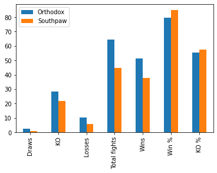

```python
mm.plot(kind='bar')
```

## 13. KOs

Southpaw fighters gain an additional edge as shown by the graph above. Although the difference is only 2%, it may be neglegable. On average, Southpaw fighters win by knockout 57.5% of the time, while Orthodox fighters win 55.5% of the time.

Although there is no evidence to show that Southpaw fighters are stronger or more powerful than Orthodox fighters, the myth we are testing is that it is more difficult for an Orthodox fighter to fight a Southpaw fighter because they are so rarely fought against. The data shows that the myth may be true with Southpaw fighters winning and getting knockouts slightly more often. This suggests that Southpaw fighters may be able to exploit gaps in their opponents training and experience, alowing then to score more points or get a knockout punch.

On the other hand, as KOs are a subset of wins, it stands to reason that KO rate will correlate with win rate.

## 14. Proportions

While looking at the graph above, I noticed that the 'total fights' bars had the greatest difference which I believe requires further investigation.

```python
# get the difference between their totals by calculating Southpaw - Orthodox
# a possitive number will show that the difference is in favour of Southpaw
# a negative number will show that the difference is in favour of Orthodox
mm['S-O, Diff'] = mm['Southpaw'] - mm['Orthodox']
# a value > 0 shows that Orthodox has a greater value than Southpaw, and vice versa
mm['proportion'] = mm['Orthodox'] / mm['Southpaw']
mm
```

|  | Orthodox | Southpaw | S-O, Diff | proportion |
| --- | --- | --- | --- | --- |
| Draws | 2.728997 | 1.075000 | -1.653997 | 2.538602 |
| KO | 28.455285 | 21.850000 | -6.605285 | 1.302301 |
| Losses | 10.449864 | 5.675000 | -4.774864 | 1.841386 |
| Total fights | 64.430894 | 44.700000 | -19.730894 | 1.441407 |
| Wins | 51.252033 | 37.950000 | -13.302033 | 1.350515 |
| Win % | 79.545741 | 84.899329 | 5.353588 | 0.936942 |
| KO % | 55.520305 | 57.575758 | 2.055453 | 0.964300 |

### 14.1 Proportions

At first glance, when looking at the difference between Southpaw and Orthodox fighters, it appears that Orthodox fighters had many more total fights on average than Southpaw fighters. At first I believed this could be evidence that Southpaw fighters may have shorter careers, or this could be the beginning of a conspiracy theory that Southpaw fighters are unfairly given fewer fights. To test this, I checked to see if these differences were proportional.

## 15. The final attempt

One final attempt was made to delve deeper into this data, but after carefully looking at the following graphs and tables i was at a loss as to where this research was taking me next. My final comment is in regards to the standard deviation for data regarding to both Southpaw and Orthodox fighters, as follows

```python
boxersData_s = boxersData.loc[boxersData["Stance"] == "Southpaw"]
```

```python
boxersData_s
```

|  | name | link | Draws | KO | Losses | Nationality | Stance | Total fights | Wins |
| --- | --- | --- | --- | --- | --- | --- | --- | --- | --- |
| 0 | William Abelyan | /wiki/William_Abelyan | 1 | 13 | 6 | Armenian | Southpaw | 31 | 24 |
| 6 | Devon Alexander | /wiki/Devon_Alexander | 1 | 14 | 7 | - | Southpaw | 35 | 27 |
| 9 | Elvis Álvarez | /wiki/Elvis_%C3%81lvarez | 3 | 19 | 8 | Colombian | Southpaw | 42 | 31 |
| 20 | Mike Arnaoutis | /wiki/Mike_Arnaoutis | 2 | 13 | 12 | - | Southpaw | 40 | 26 |
| 32 | Billy Backus | /wiki/Billy_Backus | 5 | 22 | 20 | American | Southpaw | 73 | 48 |
| ... | ... | ... | ... | ... | ... | ... | ... | ... | ... |
| 707 | Rau'shee Warren | /wiki/Rau%27shee_Warren | 0 | 5 | 4 | American | Southpaw | 23 | 19 |
| 714 | Pernell Whitaker | /wiki/Pernell_Whitaker | 1 | 17 | 4 | - | Southpaw | 45 | 40 |
| 722 | Paul Williams (boxer) | /wiki/Paul_Williams_(boxer) | 0 | 27 | 2 | - | Southpaw | 43 | 41 |
| 726 | Pongsaklek Wonjongkam | /wiki/Pongsaklek_Wonjongkam | 2 | 47 | 5 | - | Southpaw | 98 | 91 |
| 741 | Daniel Zaragoza | /wiki/Daniel_Zaragoza | 3 | 28 | 8 | - | Southpaw | 66 | 55 |

80 rows × 9 columns

### 15.1 Final observation

'std' for 'total fights' is far lower for Southpaw than for Orthodox fighters. This may be because of the range we see in the dataset with Southpaw having a range of 147 total fights and Orthodox having a range of 358. The information brings into question the reliability of this data and my findings. This is a limited dataset because Wikipedia doesn't have a list of ALL male boxers - just those famous or notable enough for someone to create an article about them.

I move to conclude.

```python
boxersData_s.describe()
```

|  | Draws | KO | Losses | Total fights | Wins |
| --- | --- | --- | --- | --- | --- |
| count | 80.000000 | 80.000000 | 80.000000 | 80.00000 | 80.000000 |
| mean | 1.075000 | 21.850000 | 5.675000 | 44.70000 | 37.950000 |
| std | 1.887836 | 10.331346 | 5.228391 | 21.35795 | 16.840954 |
| min | 0.000000 | 0.000000 | 0.000000 | 18.00000 | 16.000000 |
| 25% | 0.000000 | 14.750000 | 2.000000 | 33.75000 | 29.000000 |
| 50% | 1.000000 | 19.000000 | 5.000000 | 41.00000 | 34.500000 |
| 75% | 2.000000 | 28.500000 | 7.000000 | 49.50000 | 43.250000 |
| max | 15.000000 | 47.000000 | 27.000000 | 165.00000 | 123.000000 |

```python
boxersData_o = boxersData.loc[boxersData["Stance"] == "Orthodox"]
```

```python
boxersData_o.describe()
```

|  | Draws | KO | Losses | Total fights | Wins |
| --- | --- | --- | --- | --- | --- |
| count | 369.000000 | 369.000000 | 369.000000 | 369.000000 | 369.000000 |
| mean | 2.728997 | 28.455285 | 10.449864 | 64.430894 | 51.252033 |
| std | 5.972969 | 18.041281 | 17.274740 | 50.618202 | 37.865522 |
| min | 0.000000 | 0.000000 | 0.000000 | 1.000000 | 0.000000 |
| 25% | 0.000000 | 18.000000 | 3.000000 | 37.000000 | 31.000000 |
| 50% | 1.000000 | 25.000000 | 7.000000 | 49.000000 | 41.000000 |
| 75% | 3.000000 | 35.000000 | 12.000000 | 72.000000 | 58.000000 |
| max | 55.000000 | 126.000000 | 276.000000 | 359.000000 | 302.000000 |

## 16. Conclusion

Through this exploratory analysis of male boxers, I can conclude that there seems to be a slight competitive advantage to being Southpaw in terms of their percentage of wins to losses.

I conclude that the myth I stated in the beginning of this report is plausible at the least as there is now some evidence that shows Southpaw fighters win 5% more often, on average, than their Orthodox counterpart.

I conclude that the data analysed was reliable enough for the sake of answering this question, but more research is required to give a definitive answer to this question.

## 17. References and Resources

### References

[1]Human handedness: A meta-analysis. (Papadatou-Pastou et al., 2020)

### Resources

Web Scraping with Beautiful Soup - Make Databases from Scratch - https://www.youtube.com/watch?v=ySNSY7iiBDY

How to Scrape Wikipedia Articles with Python - https://www.freecodecamp.org/news/scraping-wikipedia-articles-with-python/

Pandas, Reference for pd.DataFrame - https://pandas.pydata.org/docs/reference/frame.html